# Introduzione a R

## Un esempio completo

Si possono mettere insieme le funzioni da `tidyverse` per ottenere più facilmente e velocemente grafici informativi sulle proprie variabili.

Ad esempio mettiamo di volere vedere la proporzione di risposte in ogni categoria di ogni item per la misurazione del benessere:

**Codice**

```r
# seleziona solo le colonne con gli id dei soggetti e gli item di benessere
new_item = benessere[, c(grep("ID", colnames(benessere)),
                        grep("item", colnames(benessere)))]
new_item = pivot_longer(new_item, # funzione di tidyverse per girare i dati
             cols = !ID,
             names_to = "item",
             values_to = "value")
```

Vanno calcolate le proporzioni per ogni categoria per ogni item

**Codice**

```r
proporzione = new_item %>%
  group_by(item, value) %>%
  summarise(prop = n()/nrow(benessere))
proporzione
```

```
# A tibble: 26 × 3
# Groups:   item [5]
   item  value  prop
   <chr> <int> <dbl>
 1 item1     1 0.193
 2 item1     2 0.293
 3 item1     3 0.227
 4 item1     4 0.133
 5 item1     5 0.153
 6 item2     1 0.187
 7 item2     2 0.313
 8 item2     3 0.187
 9 item2     4 0.18
10 item2     5 0.133
# ℹ 16 more rows
```

e infine si può otttenere il grafico:

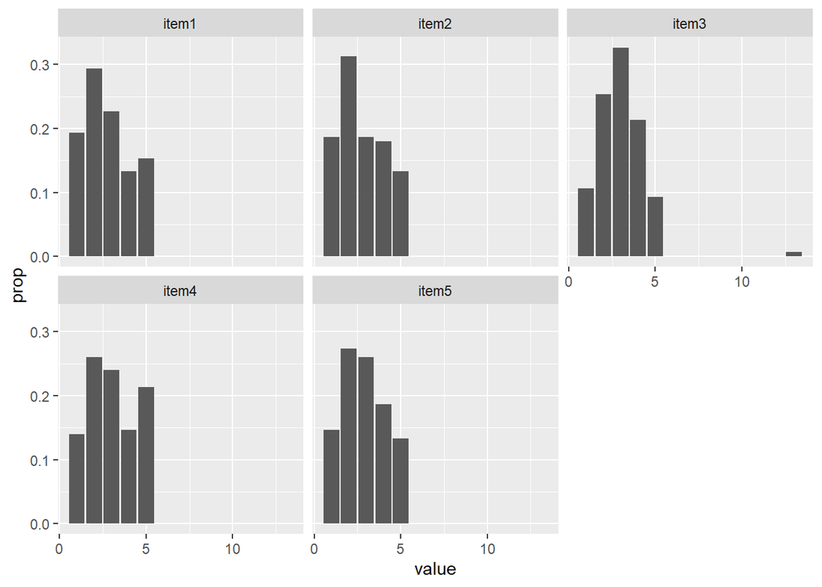

```r
ggplot(proporzione,
       aes(x = value, y = prop)) +
  geom_bar(stat = "identity") +
  facet_wrap(~item)
```

# Esportare i grafici

## Automaticamente:

```r
pdf("nome_grafico.pdf")
png("nome_grafico.png")
tiff("nome_grafico.tiff")
jpeg("nome_grafico.jpeg")
bmp("nome_grafico.bmp")
```

Ma poi bisogna ricordarsi di chiudere il device grafico con:

```r
dev.off()
```

Ad esempio, se si vuole salvare il violin plot ottenuto dai punteggi di benessere e autostima:

```r
pdf("il_mio_violin.pdf")
ggplot(score_long,
       aes(x = score, y = value,
           fill = score)) + geom_violin(trim = FALSE)
dev.off()
```

## Manualmente:

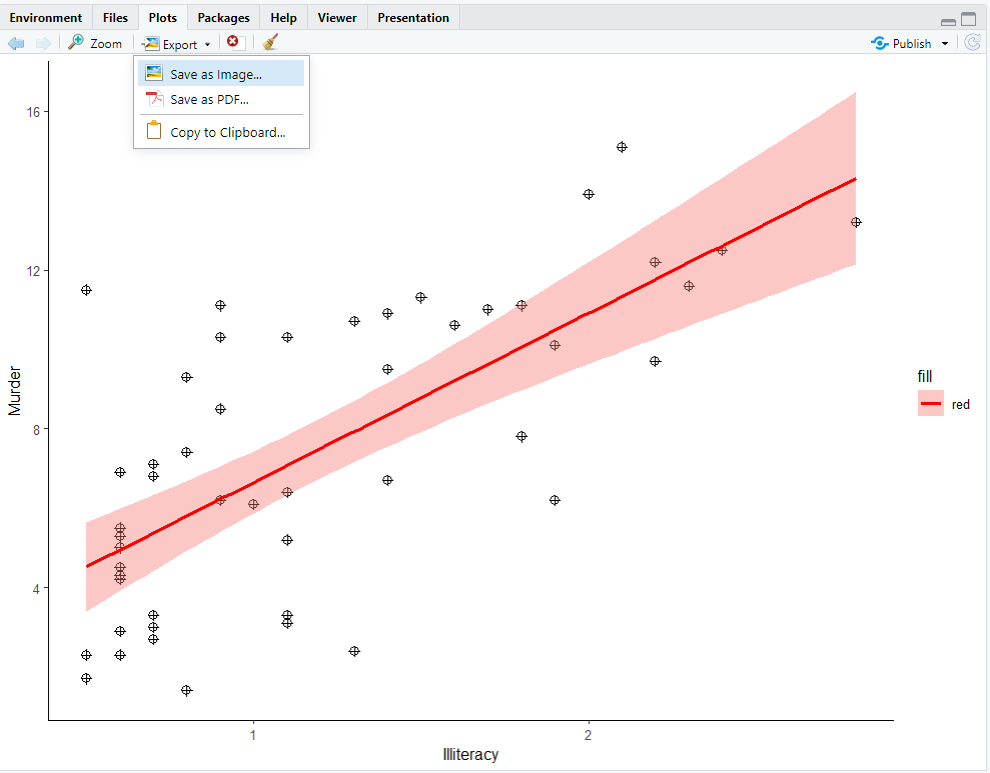